# CHDH SNA INTRO

## Power-law

In addition to standard statistical distributions, a number of models for networks have been proposed that give rise to distributions for the degree distribution. One such model, is the mathematical mechanism preferential attachment which is claimed to give rise to a degree distribution that is distributed as a *power-law* (Barabási and Albert 1999).

Liljeros et al. (2001) make very strong claims about the distribution of sex partners - take-home point is ‘is degree the only determinant of connectivity and spread?’

$$\Pr(Y=k) \propto k^{-\alpha} {\text{ , for }} k > k_c$$

Drawing on epidemiology that suggests that any disease spread on the network becomes epidemic if $\alpha \leq 3$.

In their paper, Barabási and Albert (1999), they calim extensively that that the power-law form proves that the only mechanims that is at play in networks is preferential attachement (wrong because it isn’t and there is not a one-to-one between the power-law and preferential attachement)(Robins G. L., Pattison, and Koskinen 2008)

### Modelling the degree distribution

The package `` r`'poweRlaw' `` can be used to fit different functional forms to the degree distribution. To use it first time, install it.

```r
install.packages('poweRlaw')
```

Load the package

```r
library('poweRlaw')
```

The power-law does not straightforwardly allow explantory variables so let us simply re-estimate the **log-normal** and **Poissson** without predictors for comparison. Note, the power-law **cannot handle zeros**, so now we estimate the degree distributions **conditional** on $Y_i>0$

```r
m_pl = displ$new( y[is.pos] ) # fit powerlaw
est = estimate_xmin(m_pl)# get estimates
m_pl$setXmin(est)# set the minimum vaulue
m_ln = dislnorm$new( y[is.pos] ) # fit lognormal dist
est_ln = estimate_xmin(m_ln) # set minimum value
m_ln$setXmin(est_ln)
m_pois = dispois$new( y[is.pos] ) # poisson
m_pois$setXmin(1)
est_pois = estimate_pars(m_pois)
m_pois$setPars(est_pois)
```

Note that m_pl$setXmin estimates the value of degree $k_c$ from which the power-law holds.

The program allows us to plot the fitted distrubution, more specifically the ‘survival functions’ $\Pr(Y > k)$ on a log-log scale.

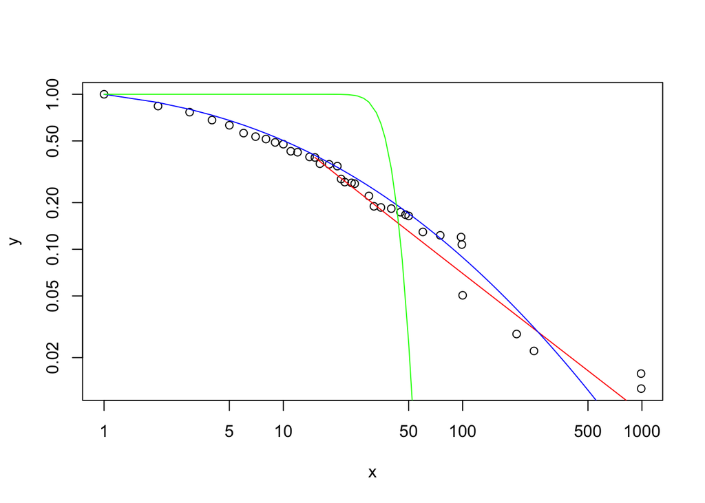

```r
plot(m_pl)# plots the raw data
lines(m_pl, col='red') # plots the power law
lines(m_ln, col='blue') # plots the lognormal
lines(m_pois, col='green') # plots the poisson
```

> What distribution seems to best fit the number of female sex partners? Two things to note: Poisson has been forced to ignore 0 and, secondly, the power-law has ignored all the information below $k_c$

## Core discussion partners

Fischer (2009) and Bailey and Marsden (1999) and others (e.g. Marsden 2003; Putnam 2001; McPherson, Smith-Lovin, and Brashears 2006) have used various waves of the GSS to investigate ‘the size’ of peoples’ networks. The size of peoples’ networks has been the target of intense speculation since Robin Dunbar (1992) proposed that there was an evolutionary limit on the number of close contacts that humans (or primates?) can retain in their brain.

The key outcome varaible in these studies has been the number of named core discussion partners

```r
table( GSSdata$numgiven , useNA= 'always')
```

```
##
##    0    1    2    3    4    5    6    9 <NA>
##  397  281  263  232  128   96   70    5 1340
```

The value 9 is a missing data code and recall that the number of named contacts is truncated at 6 - a respondent that nominated 6 or more has numgiven coded as 6 but was only allowed to provide 5 names.

As for a sociocentric network, we can plot the (truncated) degree distribution.

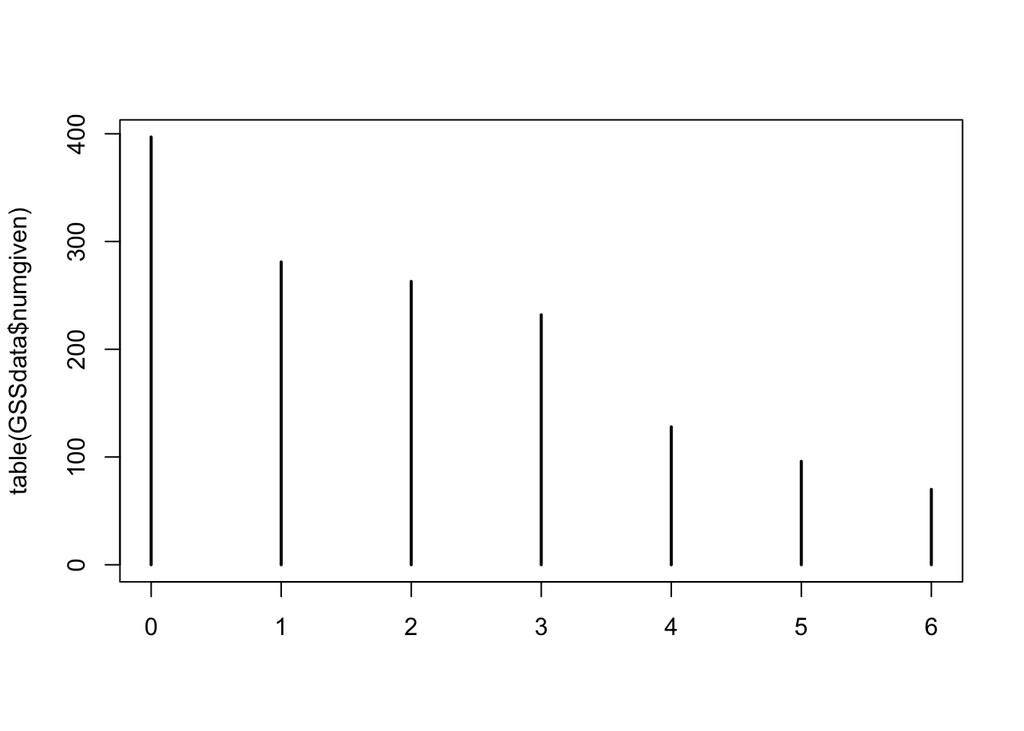

```r
GSSdata$numgiven[GSSdata$numgiven>6] <- NA
plot( table( GSSdata$numgiven ) )
```

> Without knowing the structure of the population network we can still estimate the degree distribution

### Explaining the degree distribution

As we did for sexual partners, we may try to explain the number of close contacts by using statistical tests. While both sexual partners and close contacts both have skewed degree distributions, there is one notably difference in GSS, namely the range of values. Close contacts range from zero to 6 and sexual partners range from 0 to 900 or so. This limits the use of

- approximating close contacts using a continuous distribution, and
- removing isolates (degree 0) removes an informative portion of data.

### Regressions

Close contacts might act as social support and alleviate mental health issues (Bryant et al. 2017). Can we test whether better mental health is associated with having more social support?

Create a binary variable indicating whether a respondent has experienced 1 or more days of mental ill health in the past year.

```r
GSSdata$mntlhlth[ GSSdata$mntlhlth > 30 ] <- NA # set as missing
illhealth <- GSSdata$mntlhlth>0 # this will indicate one day or more
```

### OLS

Again, assuming random normal errors

```r
reg.close.lm <- lm(GSSdata$numgiven ~ illhealth )
summary( reg.close.lm )
```

```
##
## Call:
## lm(formula = GSSdata$numgiven ~ illhealth)
##
## Residuals:
##     Min      1Q  Median      3Q     Max
## -2.2925 -1.8109 -0.2925  1.1891  4.1891
##
## Coefficients:
##               Estimate Std. Error t value Pr(>|t|)
## (Intercept)    1.81087    0.08684  20.854  < 2e-16 ***
## illhealthTRUE  0.48167    0.11679   4.124 4.05e-05 ***
## ---
## Signif. codes:  0 '***' 0.001 '**' 0.01 '*' 0.05 '.' 0.1 ' ' 1
##
## Residual standard error: 1.786 on 944 degrees of freedom
##   (1866 observations deleted due to missingness)
## Multiple R-squared:  0.0177, Adjusted R-squared:  0.01666
## F-statistic: 17.01 on 1 and 944 DF,  p-value: 4.047e-05
```

### Poisson

Using the log-link function

```r
reg.close.po <- glm(GSSdata$numgiven ~ illhealth, family = poisson(link='log') )
summary( reg.close.po )
```

```
##
## Call:
## glm(formula = GSSdata$numgiven ~ illhealth, family = poisson(link = "log"))
##
## Coefficients:
##               Estimate Std. Error z value Pr(>|z|)
## (Intercept)    0.59381    0.03613  16.435  < 2e-16 ***
## illhealthTRUE  0.23585    0.04625   5.099 3.42e-07 ***
## ---
## Signif. codes:  0 '***' 0.001 '**' 0.01 '*' 0.05 '.' 0.1 ' ' 1
##
## (Dispersion parameter for poisson family taken to be 1)
##
##     Null deviance: 1750.4  on 945  degrees of freedom
## Residual deviance: 1724.0  on 944  degrees of freedom
##   (1866 observations deleted due to missingness)
## AIC: 3687.2
##
## Number of Fisher Scoring iterations: 5
```

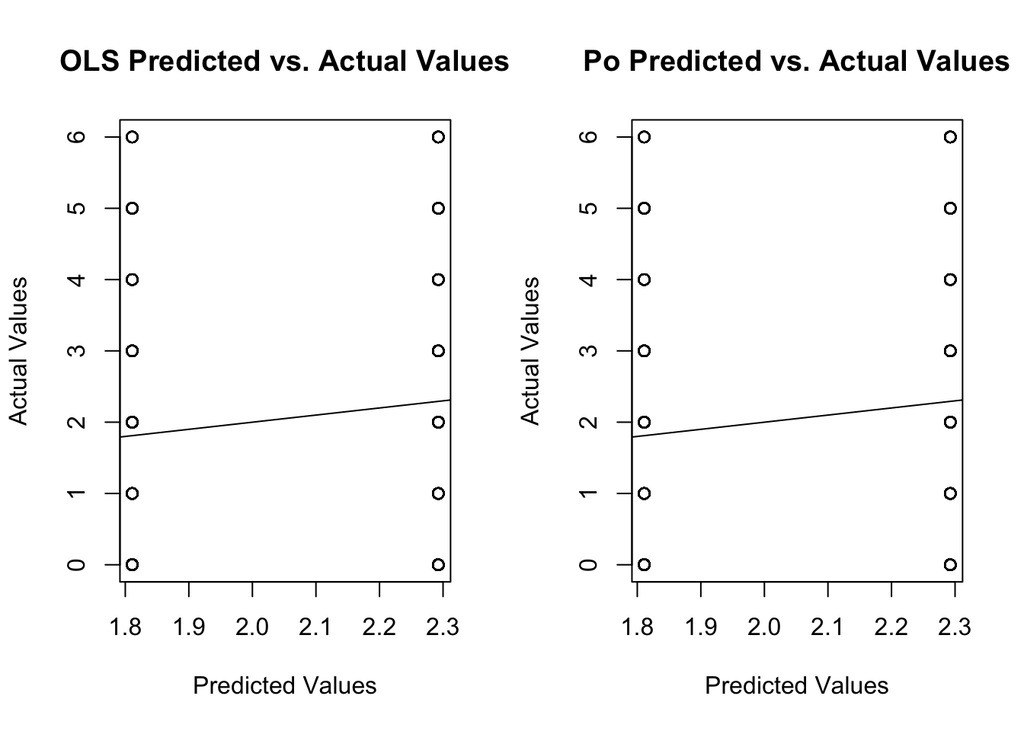

```r
par(mfrow=c(1,2))
plot(x=predict(reg.close.lm), y= GSSdata$numgiven[!is.na(GSSdata$numgiven) & !is.na(illhealth)],
     xlab='Predicted Values',
     ylab='Actual Values',
     main='OLS Predicted vs. Actual Values')
abline(a=0, b=1)

plot(x=reg.close.po$fitted.values, y=  GSSdata$numgiven[!is.na(GSSdata$numgiven) & !is.na(illhealth)],
     xlab='Predicted Values',
     ylab='Actual Values',
     main='Po Predicted vs. Actual Values')
abline(a=0, b=1)
```

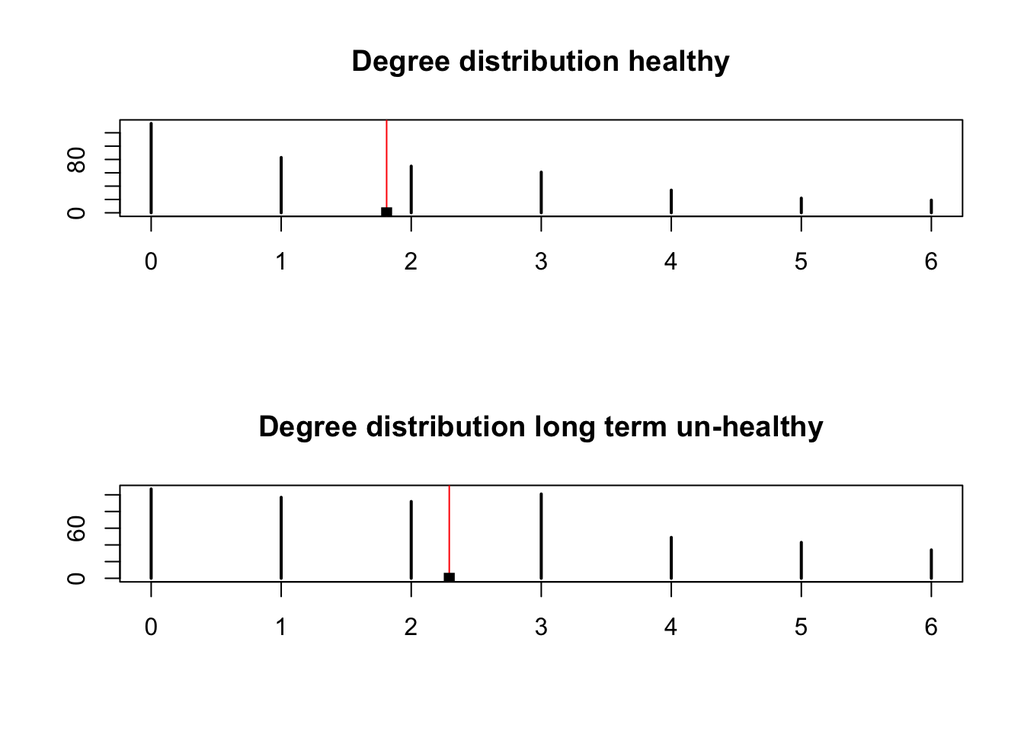

```r
par(mfrow=c(2,1))
plot(table(GSSdata$numgiven[illhealth==0]),ylab='',main='Degree distribution healthy')
abline(v=min(reg.close.po$fitted.values),col='red')
lines(mean(GSSdata$numgiven[illhealth==0],na.rm=TRUE),0,pch=15,type='p')
plot(table(GSSdata$numgiven[illhealth==1]),ylab='',main='Degree distribution long term un-healthy')
abline(v=max(reg.close.po$fitted.values),col='red')
lines(mean(GSSdata$numgiven[illhealth==1],na.rm=TRUE),0,pch=15,type='p')
```

##### Other tests

All the usual statistical tests are avaialble in R. For example ANOVA https://www.statmethods.net/stats/anova.html.

## Ego-alter ties

In addition to naming alters, each ego has also provided some basic information about each of their named alters

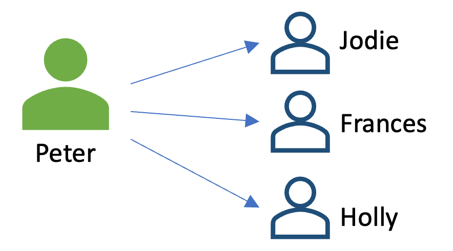

Ego-alter tie

Here we will

- transform data from the *wide format* to the so-called *long format*, so that
- each Ego-Alter pair is represented by a separate case or data point

We will use the GSS 2004

## Properties of ‘alters’

The number of named alters per person is given by the variable `numgiven`, which is the number of close contacts, truncated at 6+. For each of these named contacts, ego is providing descriptions in the form of

| Variable name | Description | Note |
| --- | --- | --- |
| SEX1 | sex of first named alter | this is NA if less than one named |
| $\vdots$ |  |  |
| SEX5 | sex of fifth named alter | this is NA if less than five named |
| RACE1 | sex of first named alter | this is NA if less than one named |
| $\vdots$ |  |  |
| RACE5 | sex of fifth named alter | this is NA if less than five named |
| TALKTO1 | Talks to first person important matters | this is NA if less than one named |
| $\vdots$ |  |  |
| TALKTO5 | Talks to first person important matters | this is NA if less than five named |
| EDUC1 | education of first named alter | this is NA if less than one named |
| $\vdots$ |  |  |
| EDUC55 | education of fifth named alter | this is NA if less than five named |

There are also a hoast of questions about commong group membership (e.g. GRPBOTH1 through GRPBOTH5) and religion, etc.

### Examples of named alters

Attributes for named alters are reported in the *wide format*: for each respondent values are reported in ascending order by alter id, variable by variable.

#### Case no nominated alters

Respondent has not named any alters, so there are no alter properties reported

```r
GSSdata[1,261:270]
```

[output not shown]

#### Case one nominated alter

Respondent has named exactly one alters, so there are only varible values for ‘SEX1’, ‘RACE1’, etc

```r
GSSdata[11,261:270]
```

[output not shown]

```r
GSSdata$SEX1[11]
```

[output not shown]

#### Case three nominated altera

Respondent has named exactly three alters, so there are three reports for each of the variables ‘SEX1’, ‘RACE1’, etc.

```r
GSSdata[13,261:270]
```

[output not shown]

```r
GSSdata[13,271:275]
```

[output not shown]

#### Case four nominated altera

Respondent has named exactly four alters, so there are four alter values to report on each variable

```r
GSSdata[16,271:275]
```

[output not shown]

```r
GSSdata[16,301:305]
```

[output not shown]

```r
GSSdata[16,306:310]
```

[output not shown]

## Homophily

For egos 13, 16 and 42, the age of their alters is given in

```r
GSSdata[c(13,16,42),c(346:350)]
```

[output not shown]

we can thus get the average age in each egonet using

```r
GSSdata$numgiven[GSSdata$numgiven>6] <- NA
ave.age <- rowSums(GSSdata[,c(346:350)], na.rm=TRUE)/GSSdata$numgiven
```

Compare the age of ego with

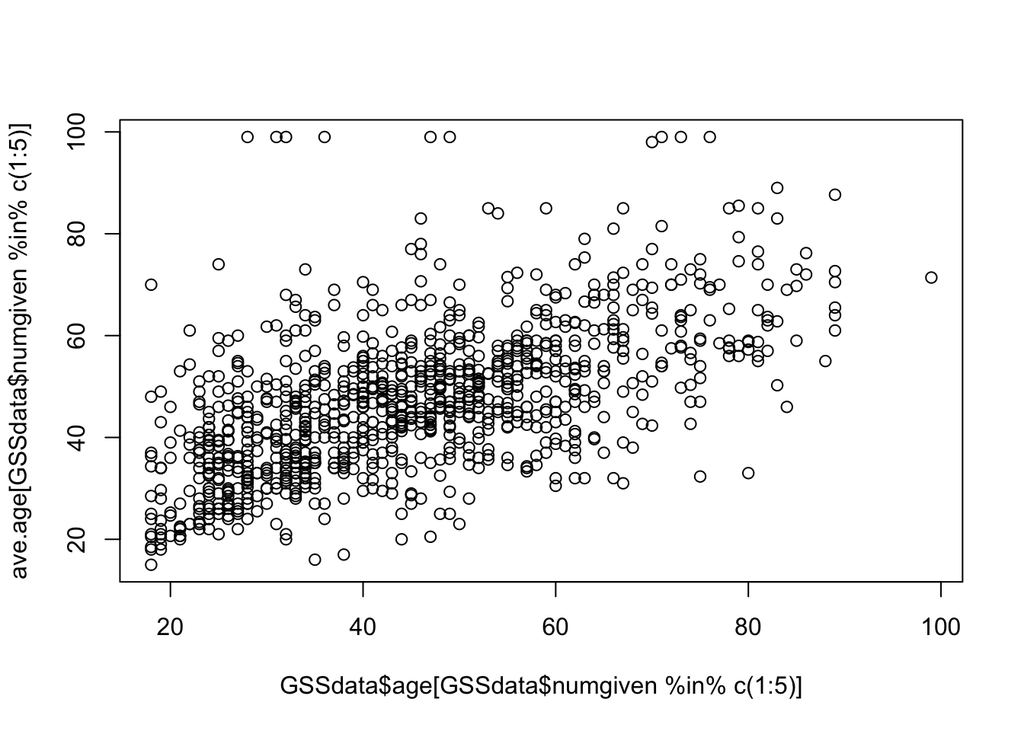

```r
plot( GSSdata$age[GSSdata$numgiven %in% c(1:5)] ,  ave.age[GSSdata$numgiven %in% c(1:5)])
```

**Homophily** (McPherson, Smith-Lovin, and Cook 2001) is the process of people choosing contacts that are like themselves. If there is homophily on age, we wold expect the averge age of alter to be predicted to the age of ego

```r
reg.age <- lm( ave.age[GSSdata$numgiven %in% c(1:5)] ~ GSSdata$age[GSSdata$numgiven %in% c(1:5)] )
summary(reg.age)
```

```
##
## Call:
## lm(formula = ave.age[GSSdata$numgiven %in% c(1:5)] ~ GSSdata$age[GSSdata$numgiven %in%
##     c(1:5)])
##
## Residuals:
##     Min      1Q  Median      3Q     Max
## -31.966  -7.673  -0.745   5.726  60.715
##
## Coefficients:
##                                           Estimate Std. Error t value Pr(>|t|)
## (Intercept)                               23.91781    1.06635   22.43   <2e-16
## GSSdata$age[GSSdata$numgiven %in% c(1:5)]  0.51310    0.02212   23.19   <2e-16
##
## (Intercept)                               ***
## GSSdata$age[GSSdata$numgiven %in% c(1:5)] ***
## ---
## Signif. codes:  0 '***' 0.001 '**' 0.01 '*' 0.05 '.' 0.1 ' ' 1
##
## Residual standard error: 11.59 on 998 degrees of freedom
## Multiple R-squared:  0.3502, Adjusted R-squared:  0.3496
## F-statistic: 537.9 on 1 and 998 DF,  p-value: < 2.2e-16
```

We can also investigate if there is homophily on race. Race is coded differently for respondents and alters so we need to recode

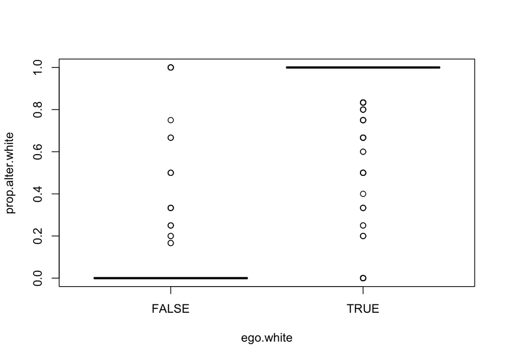

```r
ego.white <- GSSdata$race==1
alter.white <- GSSdata[,c(276,  277 , 278 , 279 , 280)]==4
prop.alter.white <- rowSums(alter.white,  na.rm=TRUE)/GSSdata$numgiven
boxplot(prop.alter.white ~ ego.white )
```

There is clear evidence of homophily on race.

#### Diversity

In terms of access to resources, it may be important to have access to different types of resources. For each ego we can tabulate the number of alters in each category

```r
alter.education <- cbind(
  rowSums(GSSdata[,c(341:345)]==0, na.rm=TRUE),
  rowSums(GSSdata[,c(341:345)]==1, na.rm=TRUE),
  rowSums(GSSdata[,c(341:345)]==2, na.rm=TRUE),
  rowSums(GSSdata[,c(341:345)]==3, na.rm=TRUE),
  rowSums(GSSdata[,c(341:345)]==4, na.rm=TRUE),
  rowSums(GSSdata[,c(341:345)]==5, na.rm=TRUE),
  rowSums(GSSdata[,c(341:345)]==6, na.rm=TRUE),
  rowSums(GSSdata[,c(341:345)]==7, na.rm=TRUE),
  rowSums(GSSdata[,c(341:345)]==8, na.rm=TRUE))
```

Based on this we can calculate the proportions $p_j$ of alters in category $j$.

```r
alter.education <- alter.education / rowSums(alter.education)# convert to proportions
```

```r
diss.index <- rowSums(alter.education^2,na.rm=TRUE)
```

## Converting to long format

**Long format** means that we code each ego-alter variable as a separate observation. Manually we can create a new data frame where alter-id is implied by ‘_1’, ‘_2’, etc.

```r
         d1 <- data.frame(id = GSSdata$id,
         egosex = GSSdata$sex,
         egoage = GSSdata$age,
         sex_1 = GSSdata$SEX1,
         sex_2 = GSSdata$SEX2,
         sex_3 = GSSdata$SEX3,
         sex_4 = GSSdata$SEX4,
         sex_5 = GSSdata$SEX5,
         talkto_1 = GSSdata$TALKTO1,
         talkto_2 = GSSdata$TALKTO2,
         talkto_3 = GSSdata$TALKTO3,
         talkto_4 = GSSdata$TALKTO4,
         talkto_5 = GSSdata$TALKTO5,
         age_1 = GSSdata$AGE1,
         age_2 = GSSdata$AGE2,
         age_3 = GSSdata$AGE3,
         age_4 = GSSdata$AGE4,
         age_5 = GSSdata$AGE5,
         cowork_1 = GSSdata$COWORK1,
         cowork_2 = GSSdata$COWORK2,
         cowork_3 = GSSdata$COWORK3,
         cowork_4 = GSSdata$COWORK4,
         cowork_5 = GSSdata$COWORK5
         )
```

This is still wide-format, but it is a data frame that only has the subset of variables that we chose. To convert it to ‘long format’, we use the reshape function

```r
egoalter <- reshape(d1, # our wide format data frame
                    dir = "long", # indicate that we want to transfrom into 'long' format
                    varying = 4:23, # variables 4 through 23 vary across egos
                    sep = "_") # this is the charachter used to indicate what ego aler belongs to

# This reshape function does not work on 'haven'-formatted data with values
```

Have a look at the new, long-format data frame

```r
head(egoalter)
```

```
##        id egosex egoage time sex talkto age cowork
## 502.1 502      2     30    1  NA     NA  NA     NA
## 578.1 578      1     32    1  NA     NA  NA     NA
## 600.1 600      2     41    1  NA     NA  NA     NA
## 863.1 863      2     39    1  NA     NA  NA     NA
## 951.1 951      1     61    1  NA     NA  NA     NA
## 991.1 991      1     35    1  NA     NA  NA     NA
```

Recode talkto to a binary variable capturing ‘almost daily’

```r
egoalter$talkto[egoalter$talkto > 4] <- NA
egoalter$talkto[egoalter$talkto>1] <- 0
```

### Multilevel model of ego-alter ties

Consider now modelling talk to almost daily as a binary variable $Y_{ij}$, where $i$ is ego and $j$ is alter
$$\mathrm{logit} (\Pr(Y_{ij}=1|z_i,x_j))=\alpha+\beta z_i +\gamma x_i +
\nu_i,$$
where $\nu_i \thicksim N(0,\tau^2)$ is a random effect for ego $i$ that is shared across all alters of $i$.

To do this using a logistic link function we need the package `lme4`

```r
library(lme4)
```

```r
 reg.talkto <- glmer(talkto ~ egoage+egosex+sex+age+cowork+(1| id), # regression formula
                     data= egoalter, # name of the data frame that holds the variables
                     family= binomial)
summary(  reg.talkto )
```

```
## Generalized linear mixed model fit by maximum likelihood (Laplace
##   Approximation) [glmerMod]
##  Family: binomial  ( logit )
## Formula: talkto ~ egoage + egosex + sex + age + cowork + (1 | id)
##    Data: egoalter
##
##       AIC       BIC    logLik -2*log(L)  df.resid
##    3759.1    3800.7   -1872.5    3745.1      2829
##
## Scaled residuals:
##     Min      1Q  Median      3Q     Max
## -2.0978 -0.8585  0.5168  0.7883  1.7916
##
## Random effects:
##  Groups Name        Variance Std.Dev.
##  id     (Intercept) 0.6548   0.8092
## Number of obs: 2836, groups:  id, 1064
##
## Fixed effects:
##              Estimate Std. Error z value Pr(>|z|)
## (Intercept)  1.783526   0.350308   5.091 3.56e-07 ***
## egoage      -0.015355   0.003378  -4.545 5.50e-06 ***
## egosex       0.358715   0.101996   3.517 0.000437 ***
## sex          0.211911   0.088154   2.404 0.016223 *
## age         -0.009880   0.003076  -3.212 0.001318 **
## cowork      -0.692913   0.136947  -5.060 4.20e-07 ***
## ---
## Signif. codes:  0 '***' 0.001 '**' 0.01 '*' 0.05 '.' 0.1 ' ' 1
##
## Correlation of Fixed Effects:
##        (Intr) egoage egosex sex    age
## egoage -0.299
## egosex -0.357  0.047
## sex    -0.274  0.002 -0.125
## age    -0.194 -0.424 -0.022 -0.015
## cowork -0.668  0.007 -0.086 -0.068 -0.024
## optimizer (Nelder_Mead) convergence code: 0 (OK)
## Model failed to converge with max|grad| = 0.00246386 (tol = 0.002, component 1)
## Model is nearly unidentifiable: very large eigenvalue
##  - Rescale variables?
```

# References

Bailey, Stefanie, and Peter V Marsden. 1999. “Interpretation and Interview Context: Examining the General Social Survey Name Generator Using Cognitive Methods.” *Social Networks* 21 (3): 287–309.

Barabási, Albert-László, and Réka Albert. 1999. “Emergence of Scaling in Random Networks.” *Science* 286 (5439): 509–12.

Borgatti, Stephen P, and Martin G Everett. 2006. “A Graph-Theoretic Perspective on Centrality.” *Social Networks* 28 (4): 466–84.

Borgatti, Stephen P, Martin G Everett, and Jeffrey C Johnson. 2018. *Analyzing Social Networks*. Sage.

Bryant, Richard A, H Colin Gallagher, Lisa Gibbs, Philippa Pattison, Colin MacDougall, Louise Harms, Karen Block, et al. 2017. “Mental Health and Social Networks After Disaster.” *American Journal of Psychiatry* 174 (3): 277–85.

Burt, Ronald S. 2009. *Structural Holes: The Social Structure of Competition*. Harvard university press.

Butts, Carter T. 2015. *_Network: Classes for Relational Data_. The Statnet Project*. https://CRAN.R-project.org/package=network.

———. 2016. *_Sna: Tools for Social Network Analysis*. https://CRAN.R-project.org/package=sna.

Coleman, James Samuel. 1964. “Introduction to Mathematical Sociology.” *Introduction to Mathematical Sociology.*

Crossley, Nick, Elisa Bellotti, Gemma Edwards, Martin G Everett, Johan Koskinen, and Mark Tranmer. 2015. *Social Network Analysis for Ego-Nets: Social Network Analysis for Actor-Centred Networks*. Sage.

Davis, J. A. 1967. “Clustering and Structural Balance in Graphs.” *Human Relations* 20: 181–87.

Davis, Mark H et al. 1980. “A Multidimensional Approach to Individual Differences in Empathy.”

Dunbar, Robin IM. 1992. “Neocortex Size as a Constraint on Group Size in Primates.” *Journal of Human Evolution* 22 (6): 469–93.

Fischer, Claude S. 2009. “The 2004 GSS Finding of Shrunken Social Networks: An Artifact?” *American Sociological Review* 74 (4): 657–69.

Freeman, Linton C. 1978. “Centrality in Social Networks Conceptual Clarification.” *Social Networks* 1 (3): 215–39.

Hage, Per, and Frank Harary. 1983. *Structural Models in Anthropology*. Cambridge: Cambridge University Press.

Hanneman, Robert A., and Mark Riddle. 2005. *Introduction to Social Network Methods*. Riverside, CA: University of California, Riverside. http://faculty.ucr.edu/~hanneman/.

Holland, P. W., and S. Leinhardt. 1972. “Local Structure in Social Networks.” In *Sociological Methodology*, edited by Heise D., 2:1–45. 5th Series. San Francisco, CAn: Jossey-Bass.

Igarashi, Tasuku, and Johan Koskinen. 2020. “Overchoosing: A Mechanism of Tie-Formation in Social Networks.” https://psyarxiv.com/47q39.

Kapferer, Bruce. 1972. *Strategy and Transaction in an African Factory: African Workers and Indian Management in a Zambian Town*. Manchester University Press.

Liljeros, Fredrik, Christofer R Edling, Luis A Nunes Amaral, H Eugene Stanley, and Yvonne Åberg. 2001. “The Web of Human Sexual Contacts.” *Nature* 411 (6840): 907–8.

Marsden, Peter V. 2003. “Interviewer Effects in Measuring Network Size Using a Single Name Generator.” *Social Networks* 25 (1): 1–16.

McPherson, Miller, Lynn Smith-Lovin, and Matthew E Brashears. 2006. “Social Isolation in America: Changes in Core Discussion Networks over Two Decades.” *American Sociological Review* 71 (3): 353–75.

McPherson, Miller, Lynn Smith-Lovin, and James M Cook. 2001. “Birds of a Feather: Homophily in Social Networks.” *Annual Review of Sociology* 27 (1): 415–44.

Morris, Martina. 2004. *Network Epidemiology: A Handbook for Survey Design and Data Collection*. Oxford University Press on Demand.

Padgett, John F, and Christopher K Ansell. 1993. “Robust Action and the Rise of the Medici, 1400-1434.” *American Journal of Sociology* 98 (6): 1259–319.

Putnam, Robert. 2001. “Social Capital: Measurement and Consequences.” *Canadian Journal of Policy Research* 2 (1): 41–51.

Read, Kenneth E. 1954. “Cultures of the Central Highlands, New Guinea.” *Southwestern Journal of Anthropology*, 1–43.

Robins, G. L., Pattison P. E., and J. H. Koskinen. 2008. “Network Degree Distributions.” MelNet Social Networks Laboratory Technical Report 08-02. Department of Psychology, School of Behavioural Science, University of Melbourne.

Robins, Garry. 2015. *Doing Social Network Research: Network-Based Research Design for Social Scientists*. Sage.

Rosenberg, Morris. 2015. *Society and the Adolescent Self-Image*. Princeton university press.

Rotter, Julian B. 1966. “Generalized Expectancies for Internal Versus External Control of Reinforcement.” *Psychological Monographs: General and Applied* 80 (1): 1.

Scheier, Michael F, Charles S Carver, and Michael W Bridges. 1994. “Distinguishing Optimism from Neuroticism (and Trait Anxiety, Self-Mastery, and Self-Esteem): A Reevaluation of the Life Orientation Test.” *Journal of Personality and Social Psychology* 67 (6): 1063.

Simpson, Edward H. 1949. “Measurement of Diversity.” *Nature* 163 (4148): 688–88.

Spiegelhalter, David. 2015. *Sex by Numbers: What Statistics Can Tell Us about Sexual Behaviour*. Profile books LTD, London.

Stys, Patrycja, Judith Verweijen, Papy Muzuri, Samuel Muhindo, Christoph Vogel, and Johan H Koskinen. 2020. “Brokering Between (Not so) Overt and (Not so) Covert Networks in Conflict Zones.” *Global Crime* 21 (1): 74–110.

Yamagishi, Toshio. 1986. “The Provision of a Sanctioning System as a Public Good.” *Journal of Personality and Social Psychology* 51 (1): 110.